# Replication of Alt et al. (2014) with Corrected Election Timing Data

Christopher Gandrud

27 October 2014

**Working Draft. Comments Welcome.**[^1]

> This note replicates Alt, Lassen, and Wehner (2014) using corrected election timing data. They tested a key proposition–that politicians use creative accounting before elections conditional on the level of fiscal transparency–with election timing data from the 2012 release of (Beck et al. 2001). This data, however, has serious reliability and validity issues. The purpose of this note is to discover if the main findings in Alt, Lassen, and Wehner (2014) are robust with an election timing measure that corrects these issues. Overall the results are robust, though the estimated effects’ magnitudes and statistical significance are lower than originally reported. As such, this note provides estimates of the effects of election timing on European fiscal gimmickry that are not biased by issues in the original election timing variable’s measurement.

Alt, Lassen, and Wehner (2014) recently made an important contribution to understanding under what conditions European politicians use creative accounting, otherwise known as fiscal gimmicks. They find evidence for an electoral cycle in fiscal gimmickry. Politicians are more likely to use creative accounting closer to approaching elections in order to forestall adjustments that would hurt voters while also presenting an impression of their finances that pleases bondholders and, in the European Union, European officials that monitor the Stability and Growth Pact. Opacity is required for this behaviour to work. As such, they find that higher fiscal transparency can considerably decrease creative accounting, even before elections.

Their empirical analysis clearly requires a reliable and valid measure of election timing. As such, they choose to use the chief executive election timing variable–YRCURNT–from the 2012 version of the Database of Political Institutions (DPI) (Beck et al. 2001).[^2] The DPI data set is widely used in political science and has over 2000 citations as of September 2014 according to Google Scholar.

## Problems with DPI government election timing data

The 2012 DPI Codebook[^3] classifies the election timing variable as the years left in the chief executive’s current term such that:

> “a ‘0’ is scored in an election year, and n-1 in the year after an election, where n is the length of the term. In countries where early elections can be called, YRCURNT is set to the de jure term limit or schedule of elections, but resets in the case of early elections.’’

### Issues in the 2012 data

The original variable has a number of validity and reliability issues that make it problematic for studying the effect of election timing on government policymaking. Primarily:

#### Validity concerns

- For Austria the elections recorded are for a largely figurehead president. This can affect both when elections are recorded and how many years are recorded until the next election, as the figurehead president has a longer term than the parliament. In this cases the 2012 version of the variable is not a valid measure of *government* election timing.
- Some countries are less clear cut in that they are semi-presidential. Nonetheless, in a number of these cases (e.g. Romania), the PM is the clear leader of the government and the domestic policy agenda. These powers are most relevant for studying things like public budgeting.

#### Reliability concerns

- There are many instances where election years are not recorded as 0, as the coding scheme defines. See the table below for details.

## Updated Data

To correct these issues, I validated the DPI election timing data was for 27 European Union countries (the same sample as Alt, Lassen, and Wehner (2014) used). I validated data from 1990 to the present using the European Election Database (2014). These election dates were corroborated with data from Wikipedia. Election dates from before 1990 are also from Wikipedia. All elections examined in the European Election Database had a corresponding detailed Wikipedia entry describing key election features, including the election date and vote distributions. The corrected data can be found at https://github.com/christophergandrud/yrcurnt_corrected. The full list of changes are given in the following table.

### List of Changes to DPI Cheif Executive Election Timing Variable (**yrcurnt**)

[output not shown]

### Comparing original vs. Corrected data

17 of the 27 countries required some corrections. The bulk of these corrections were in the post-2000 period. Many countries are simply missing elections in the 2000s period. The original and corrected data are relatively highly correlated at 0.87. As most of the corrections were made to the post-2000 the correlation in this period between the two series is expectedly lower at 0.75.

To further illustrate the bias introduced in the original variable, the following figure plots the original values compared to the residual of the original and corrected values (e.g. original - corrected). The points are jittered to make them easier to see. A residual of 0 clearly indicates that an observation was not corrected.

### Figure 1: Original vs. Residual of Corrected Election Timing Variable

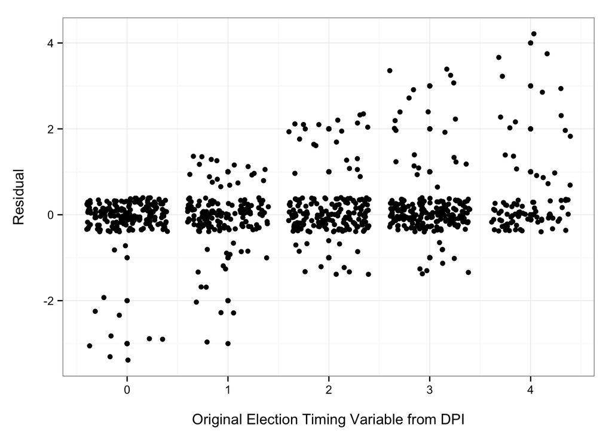

## Results from replication of Alt et al. (2014) with corrected election timing data

The following tables replicate the main regression results from Alt, Lassen, and Wehner (2014). Their original results tables can be found in Appendix 7 from the Supplemental Materials attached to the article.[^4] The replications were done in Stata 12.1 using the Do-file and data made available by the authors in the Supplemental Materials. In the following tables *Election timing* indicates the YRCURNT (original or corrected) variable.

### Table 1: Balance

|  | Dependent variable | Original | Corrected |
| --- | --- | --- | --- |
| 1 | Electoral Term | 0.67** | 0.63** |
| 2 |  | (0.25) | (0.28) |
| 3 | Electoral term x Budget transparency | -0.69** | -0.69* |
| 4 |  | (0.31) | (0.36) |
| 5 | SGP | 13.15*** | 13.00*** |
| 6 |  | (3.24) | (3.29) |
| 7 | SGP x Budget transparency | -11.61*** | -11.35*** |
| 8 |  | (3.39) | (3.48) |
| 9 | Slump | 4.17*** | 4.10*** |
| 10 |  | (0.68) | (0.67) |
| 11 | Slump x Budget transparency | -6.54*** | -6.41*** |
| 12 |  | (1.01) | (1.00) |
| 13 | Boom | -0.73* | -0.67* |
| 14 |  | (0.39) | (0.36) |
| 15 | Boom x Budget transparency | 1.31** | 1.23** |
| 16 |  | (0.50) | (0.47) |
| 17 | Banking crisis | -2.38*** | -2.47*** |
| 18 |  | (0.73) | (0.72) |
| 54 | N | 219 | 219 |
| 58 | No. of Countries | 14 | 14 |

### Table 2: Debt change

|  | Dependent variable | Original | Corrected |
| --- | --- | --- | --- |
| 1 | Electoral Term | -3.58*** | -2.70*** |
| 2 |  | (0.88) | (0.88) |
| 3 | Electoral term x Budget transparency | 4.54*** | 3.28** |
| 4 |  | (1.24) | (1.27) |
| 5 | SGP | -3.49 | -3.71 |
| 6 |  | (5.72) | (5.76) |
| 7 | SGP x Budget transparency | 0.02 | -0.03 |
| 8 |  | (5.98) | (6.10) |
| 9 | Slump | -0.10 | -0.16 |
| 10 |  | (1.55) | (1.54) |
| 11 | Slump x Budget transparency | 0.69 | 0.79 |
| 12 |  | (2.16) | (2.15) |
| 13 | Boom | 1.65** | 1.56** |
| 14 |  | (0.76) | (0.69) |
| 15 | Boom x Budget transparency | -2.80** | -2.67** |
| 16 |  | (1.10) | (1.01) |
| 17 | Banking crisis | 3.68*** | 3.41*** |
| 18 |  | (1.09) | (1.09) |
| 54 | N | 219 | 219 |
| 58 | No. of Countries | 14 | 14 |

### Table 3: SFA

|  | Dependent variable | Original | Corrected |
| --- | --- | --- | --- |
| 1 | Electoral Term | -2.92*** | -2.07** |
| 2 |  | (0.80) | (0.87) |
| 3 | Electoral term x Budget transparency | 3.85*** | 2.58* |
| 4 |  | (1.13) | (1.29) |
| 5 | SGP | 9.66*** | 9.29*** |
| 6 |  | (3.04) | (3.06) |
| 7 | SGP x Budget transparency | -11.59*** | -11.38*** |
| 8 |  | (3.46) | (3.49) |
| 9 | Slump | 4.08** | 3.94** |
| 10 |  | (1.41) | (1.40) |
| 11 | Slump x Budget transparency | -5.85*** | -5.62*** |
| 12 |  | (1.83) | (1.83) |
| 13 | Boom | 0.93 | 0.89 |
| 14 |  | (0.69) | (0.69) |
| 15 | Boom x Budget transparency | -1.49 | -1.44 |
| 16 |  | (1.11) | (1.11) |
| 17 | Banking crisis | 1.30 | 0.94 |
| 18 |  | (1.29) | (1.33) |
| 54 | N | 219 | 219 |
| 58 | No. of Countries | 14 | 14 |

### Table 4: SFA (excluding Greece)

|  | Dependent variable | Original | Corrected |
| --- | --- | --- | --- |
| 1 | Electoral Term | -2.18*** | -1.36** |
| 2 |  | (0.50) | (0.56) |
| 3 | Electoral term x Budget transparency | 2.87*** | 1.67* |
| 4 |  | (0.72) | (0.88) |
| 5 | SGP | 10.32** | 9.94** |
| 6 |  | (4.01) | (4.03) |
| 7 | SGP x Budget transparency | -12.39** | -12.09** |
| 8 |  | (5.41) | (5.44) |
| 9 | Slump | 3.88 | 3.71 |
| 10 |  | (2.25) | (2.22) |
| 11 | Slump x Budget transparency | -5.51* | -5.24* |
| 12 |  | (2.98) | (2.94) |
| 13 | Boom | 0.64 | 0.72 |
| 14 |  | (1.26) | (1.22) |
| 15 | Boom x Budget transparency | -1.05 | -1.17 |
| 16 |  | (1.90) | (1.85) |
| 17 | Banking crisis | 0.84 | 0.59 |
| 18 |  | (1.26) | (1.31) |
| 54 | N | 203 | 203 |
| 58 | No. of Countries | 13 | 13 |

### Table 5: Net acquisition (+) of shares and other equity

|  | Dependent variable | Original | Corrected |
| --- | --- | --- | --- |
| 1 | Electoral Term | -1.76*** | -1.18** |
| 2 |  | (0.19) | (0.42) |
| 3 | Electoral term x Budget transparency | 2.29*** | 1.57** |
| 4 |  | (0.28) | (0.52) |
| 5 | SGP | 6.26** | 7.66* |
| 6 |  | (1.90) | (3.23) |
| 7 | SGP x Budget transparency | -7.29** | -9.12* |
| 8 |  | (2.42) | (4.11) |
| 9 | Slump | 1.33 | 1.89 |
| 10 |  | (0.88) | (1.33) |
| 11 | Slump x Budget transparency | -1.86 | -2.62 |
| 12 |  | (1.14) | (1.76) |
| 13 | Boom | 0.55** | 0.86*** |
| 14 |  | (0.16) | (0.18) |
| 15 | Boom x Budget transparency | -0.89*** | -1.33*** |
| 16 |  | (0.20) | (0.21) |
| 17 | Banking crisis | 0.67 | 0.37 |
| 18 |  | (0.40) | (0.35) |
| 54 | N | 77 | 77 |
| 58 | No. of Countries | 6 | 6 |

### Table 6: Net incurrence (-) of other liabilities

|  | Dependent variable | Original | Corrected |
| --- | --- | --- | --- |
| 1 | Electoral Term | -0.77** | -0.51** |
| 2 |  | (0.24) | (0.19) |
| 3 | Electoral term x Budget transparency | 1.05** | 0.73** |
| 4 |  | (0.31) | (0.27) |
| 5 | SGP | -1.58 | -1.06 |
| 6 |  | (1.01) | (1.58) |
| 7 | SGP x Budget transparency | 2.14 | 1.48 |
| 8 |  | (1.32) | (2.09) |
| 9 | Slump | -0.75 | -0.56 |
| 10 |  | (0.73) | (0.73) |
| 11 | Slump x Budget transparency | 1.33 | 1.08 |
| 12 |  | (0.98) | (0.91) |
| 13 | Boom | -0.02 | 0.10 |
| 14 |  | (0.44) | (0.49) |
| 15 | Boom x Budget transparency | -0.01 | -0.18 |
| 16 |  | (0.66) | (0.73) |
| 17 | Banking crisis | 0.71 | 0.46 |
| 18 |  | (0.72) | (0.71) |
| 54 | N | 77 | 77 |
| 58 | No. of Countries | 6 | 6 |

References

Alt, James, David Dreyer Lassen, and Joachim Wehner. 2014. “It Isn’t Just About Greece: Domestic Politics, Transparency and Fiscal Gimmickry in Europe.” *British Journal of Political Science* 44 (04): 707–16.

Beck, Thorsten, George Clarke, Alberto Groff, Philip Keefer, and Patrick Walsh. 2001. “New Tools in Comparative Political Economy: The Database of Political Institutions.” *World Bank Economic Review* 15 (1).

Services, Norwegian Social Science Data. 2014. “European Election Database.”

[^1]: All replication materials for this note can be found at: https://github.com/christophergandrud/Alt_et_al_2014_Replication
[^2]: Available at: http://go.worldbank.org/2EAGGLRZ40. Accessed September 2014.
[^3]: Available at: http://siteresources.worldbank.org/INTRES/Resources/469232-1107449512766/DPI2012_Codebook2.pdf. Accessed September 2014.
[^4]: Appendix 7 can be found at: http://journals.cambridge.org/action/displaySuppMaterial?cupCode=1&type=4&jid=JPS&volumeId=44&issueId=04&aid=9345189&sessionId=7478A414E0A5039EB5DDE864C1B54332.journals.